# Analysis of Flight Data using DuckDB

Author

DAPT 621 Intro to R

## Objective

We’ll uncover delay trends with flights in 2022 and early 2023 using a large dataset of airline on-time performance from the [Bureau of Transportation Statistics](https://www.transtats.bts.gov/DL_SelectFields.aspx?gnoyr_VQ=FGK&QO_fu146_anzr=b0-gvzr) (compiled dataset from [Kaggle](https://www.kaggle.com/datasets/arvindnagaonkar/flight-delay)).

Data wrangling process:

- Import helper data from Excel using the `readxl` library.
- Import a compressed large dataset in parquet format using the Apache `arrow` library
- Create an in-process database using `duckdb` to analyze the data with SQL
- Utilize the `duckdb` framework in order to process data more efficiently
- Use joins (`dplyr` `left_join`) in order to combine data

## Load data

### Load needed libraries

We’ll again use the `tidyverse` suite of packages like `dplyr`, `readxl`, and `ggplot2` and others to work with the flight data.

```r
library(dplyr) # data manipulation
library(readxl) # work with Excel data
library(arrow) # work with parquet data
library(lubridate) # work with dates
library(duckdb) # create and use a database
library(DBI) # functions to interface with database, already loaded with duckdb
library(dbplyr) # translate dplyr code to SQL
library(ggplot2) # visualization
```

### Load lookup tables from excel file

`read_excel` is a function within the `readxl` package designed to read data from Excel workbooks. There are other R packages designed for this (`openxlsx` is another good one for importing and creating workbooks).

```r
filepath <- 'lookup_tables.xlsx'
sample <- read_excel(path = filepath, sheet = 'sample')
carriers <- read_excel(path = filepath, sheet = 'carriers')
holidays <- read_excel(path = filepath, sheet = 'holidays')
```

### Load Parquet file

[Parquet](https://parquet.apache.org/) is an open source, column-oriented data format with efficient data compression created by Apache.

```r
flight_data <- read_parquet('flight_delay_2022_2023.parquet')
```

## Data Wrangling on Sample

### Join data with `left_join()`

Use a join to bring in carrier names and identify holidays. A left join will retain all rows from the first listed table.

#### Add Carrier Names

```r
sample <- left_join(
    x = sample,
    y = carriers,
    by = join_by(Marketing_Airline_Network == Code)
    )
```

```r
sample %>% select(Marketing_Airline_Network, CarrierName) %>% head(5)
```

```
# A tibble: 5 × 2
  Marketing_Airline_Network CarrierName
  <chr>                     <chr>
1 WN                        Southwest Airlines Co.
2 G4                        Allegiant Air
3 DL                        Delta Air Lines Inc.
4 WN                        Southwest Airlines Co.
5 UA                        United Air Lines Inc.
```

#### Holidays

```r
sample <- left_join(
    x = sample,
    y = holidays,
    by = join_by(FlightDate == Date)
    )
```

```r
sample %>%
  group_by(Holiday) %>%
  summarise(
    num_flights = n()
  )
```

```
# A tibble: 8 × 2
  Holiday                                         num_flights
  <chr>                                                 <int>
1 Christmas Day (Observed)                                  1
2 Good Friday                                               1
3 Independence Day                                          2
4 Juneteenth National Independence Day (Observed)           2
5 Labor Day                                                 3
6 New Year's Day (Observed)                                 1
7 Presidents' Day                                           1
8 <NA>                                                    489
```

### Add day of week with `lubridate`

The `lubridate` package has many good functions to make working with dates easier. The `wday()` function will identify the day of the week from a date.

#### Example

```r
# get today's date
date_today <- today()

# return the numeric day of the week
wday(date_today)
```

```
[1] 7
```

```r
# return the labeled day of the week
wday(date_today, label = TRUE)
```

```
[1] Sat
Levels: Sun < Mon < Tue < Wed < Thu < Fri < Sat
```

#### Add DayofWeek column to the data

```r
sample <- sample %>%
  mutate(
    DayofWeek = wday(FlightDate, label = TRUE)
  )
```

```r
sample %>%
  select(FlightDate, DayofWeek) %>%
  head(5)
```

```
# A tibble: 5 × 2
  FlightDate          DayofWeek
  <dttm>              <ord>
1 2022-06-29 00:00:00 Wed
2 2022-07-21 00:00:00 Thu
3 2023-04-26 00:00:00 Wed
4 2022-06-19 00:00:00 Sun
5 2022-06-05 00:00:00 Sun
```

## Create a database of the data

### Set up database connection

DuckDB and SQLite only needs a path to the database. Here, “:memory:” is a special path that creates an in-memory database. Other database drivers will require more details (like user, password, host, port, etc.).

```r
drv <- duckdb() # driver
con <- DBI::dbConnect(drv) # connection
```

### Write the carriers, holidays, and flight_data tables

```r
DBI::dbWriteTable(conn = con, name = 'carrier_tbl', value = carriers)
DBI::dbWriteTable(conn = con, name = 'holiday_tbl', value = holidays)

DBI::dbWriteTable(conn = con, name = 'flights', value = flight_data)
# if error, try flight_data <- as.data.frame(flight_data) before writing table to convert from tibble to data.frame object
```

### List tables in the database

```r
dbListTables(con)
```

```
[1] "carrier_tbl" "flights"     "holiday_tbl"
```

### Read a table from the database

View as a data frame.

```r
con %>%
    dbReadTable('flights') %>%
    head(5)
```

```
  Year Month DayofMonth FlightDate Marketing_Airline_Network
1 2022     1          6 2022-01-06                        DL
2 2022     1          6 2022-01-06                        DL
3 2022     1          6 2022-01-06                        DL
4 2022     1          6 2022-01-06                        DL
5 2022     1          6 2022-01-06                        DL
         OriginCityName          DestCityName CRSDepTime DepTime DepDelay
1           Atlanta, GA   Fort Lauderdale, FL       1631    1627       -4
2   Fort Lauderdale, FL           Atlanta, GA       1931    1929       -2
3   Fort Lauderdale, FL    Raleigh/Durham, NC       1024    1019       -5
4           Atlanta, GA Jackson/Vicksburg, MS       1117    1113       -4
5 Jackson/Vicksburg, MS           Atlanta, GA       1237    1230       -7
  DepDelayMinutes TaxiOut WheelsOff WheelsOn TaxiIn CRSArrTime ArrTime ArrDelay
1               0      15      1642     1815      5       1821    1820       -1
2               0      13      1942     2105     10       2127    2115      -12
```

[output cut: 21 more lines]

View as a tibble (tidyverse data frame format).

```r
con %>%
    dbReadTable('flights') %>%
    as_tibble() %>%
    head(5)
```

```
# A tibble: 5 × 30
   Year Month DayofMonth FlightDate Marketing_Airline_Network OriginCityName
  <int> <int>      <int> <chr>      <chr>                     <chr>
1  2022     1          6 2022-01-06 DL                        Atlanta, GA
2  2022     1          6 2022-01-06 DL                        Fort Lauderdale, …
3  2022     1          6 2022-01-06 DL                        Fort Lauderdale, …
4  2022     1          6 2022-01-06 DL                        Atlanta, GA
5  2022     1          6 2022-01-06 DL                        Jackson/Vicksburg…
# ℹ 24 more variables: DestCityName <chr>, CRSDepTime <int>, DepTime <dbl>,
#   DepDelay <dbl>, DepDelayMinutes <dbl>, TaxiOut <dbl>, WheelsOff <dbl>,
#   WheelsOn <dbl>, TaxiIn <dbl>, CRSArrTime <int>, ArrTime <dbl>,
#   ArrDelay <dbl>, ArrDelayMinutes <dbl>, CRSElapsedTime <dbl>,
#   ActualElapsedTime <dbl>, AirTime <dbl>, Distance <dbl>,
#   DistanceGroup <int>, CarrierDelay <dbl>, WeatherDelay <dbl>,
#   NASDelay <dbl>, SecurityDelay <dbl>, LateAircraftDelay <dbl>, …
```

## Use SQL to query

Now that tables exist in a database, SQL can be used to query the data.

```r
sql <- "
    SELECT *
    FROM flights
    WHERE OriginCityName = 'Richmond, VA'
    LIMIT 10
"
```

```r
dbGetQuery(con, sql)
```

```
   Year Month DayofMonth FlightDate Marketing_Airline_Network OriginCityName
1  2022     1          6 2022-01-06                        DL   Richmond, VA
2  2022     1          6 2022-01-06                        DL   Richmond, VA
3  2022     1          7 2022-01-07                        DL   Richmond, VA
4  2022     1          7 2022-01-07                        DL   Richmond, VA
5  2022     1          7 2022-01-07                        DL   Richmond, VA
6  2022     1          7 2022-01-07                        DL   Richmond, VA
7  2022     1         15 2022-01-15                        DL   Richmond, VA
8  2022     1         15 2022-01-15                        DL   Richmond, VA
9  2022     1         15 2022-01-15                        DL   Richmond, VA
10 2022     1         15 2022-01-15                        DL   Richmond, VA
   DestCityName CRSDepTime DepTime DepDelay DepDelayMinutes TaxiOut WheelsOff
1   Atlanta, GA        900     857       -3               0      13       910
2   Atlanta, GA       1755    1906       71              71      10      1916
3   Atlanta, GA       1100    1106        6               6      10      1116
```

[output cut: 40 more lines]

```r
dbGetQuery(con, sql) %>% as_tibble()
```

```
# A tibble: 10 × 30
    Year Month DayofMonth FlightDate Marketing_Airline_Network OriginCityName
   <int> <int>      <int> <chr>      <chr>                     <chr>
 1  2022     1          6 2022-01-06 DL                        Richmond, VA
 2  2022     1          6 2022-01-06 DL                        Richmond, VA
 3  2022     1          7 2022-01-07 DL                        Richmond, VA
 4  2022     1          7 2022-01-07 DL                        Richmond, VA
 5  2022     1          7 2022-01-07 DL                        Richmond, VA
 6  2022     1          7 2022-01-07 DL                        Richmond, VA
 7  2022     1         15 2022-01-15 DL                        Richmond, VA
 8  2022     1         15 2022-01-15 DL                        Richmond, VA
 9  2022     1         15 2022-01-15 DL                        Richmond, VA
10  2022     1         15 2022-01-15 DL                        Richmond, VA
# ℹ 24 more variables: DestCityName <chr>, CRSDepTime <int>, DepTime <dbl>,
#   DepDelay <dbl>, DepDelayMinutes <dbl>, TaxiOut <dbl>, WheelsOff <dbl>,
#   WheelsOn <dbl>, TaxiIn <dbl>, CRSArrTime <int>, ArrTime <dbl>,
#   ArrDelay <dbl>, ArrDelayMinutes <dbl>, CRSElapsedTime <dbl>,
#   ActualElapsedTime <dbl>, AirTime <dbl>, Distance <dbl>,
#   DistanceGroup <int>, CarrierDelay <dbl>, WeatherDelay <dbl>,
#   NASDelay <dbl>, SecurityDelay <dbl>, LateAircraftDelay <dbl>, …
```

## Use `dbplyr` to query

`dbplyr` is a `dplyr` backend that allows you to write with dplyr syntax while the backend translates this R code to SQL.

### Step 1 - `tbl()`

In order to use `dbplyr`, a database table first needs to be converted to a database `tbl()` object in R.

```r
flights_db <- tbl(con, 'flights')
```

### Use dplyr syntax to query

```r
flights_db %>%
  filter(OriginCityName == 'Richmond, VA') %>%
  head(10)
```

```
# Source:   SQL [10 x 30]
# Database: DuckDB v0.9.2 [dmark@Windows 10 x64:R 4.3.1/:memory:]
    Year Month DayofMonth FlightDate Marketing_Airline_Network OriginCityName
   <int> <int>      <int> <chr>      <chr>                     <chr>
 1  2022     1          6 2022-01-06 DL                        Richmond, VA
 2  2022     1          6 2022-01-06 DL                        Richmond, VA
 3  2022     1          7 2022-01-07 DL                        Richmond, VA
 4  2022     1          7 2022-01-07 DL                        Richmond, VA
 5  2022     1          7 2022-01-07 DL                        Richmond, VA
 6  2022     1          7 2022-01-07 DL                        Richmond, VA
 7  2022     1         15 2022-01-15 DL                        Richmond, VA
 8  2022     1         15 2022-01-15 DL                        Richmond, VA
 9  2022     1         15 2022-01-15 DL                        Richmond, VA
10  2022     1         15 2022-01-15 DL                        Richmond, VA
# ℹ 24 more variables: DestCityName <chr>, CRSDepTime <int>, DepTime <dbl>,
#   DepDelay <dbl>, DepDelayMinutes <dbl>, TaxiOut <dbl>, WheelsOff <dbl>,
#   WheelsOn <dbl>, TaxiIn <dbl>, CRSArrTime <int>, ArrTime <dbl>,
#   ArrDelay <dbl>, ArrDelayMinutes <dbl>, CRSElapsedTime <dbl>,
#   ActualElapsedTime <dbl>, AirTime <dbl>, Distance <dbl>,
#   DistanceGroup <int>, CarrierDelay <dbl>, WeatherDelay <dbl>,
#   NASDelay <dbl>, SecurityDelay <dbl>, LateAircraftDelay <dbl>, …
```

### Use dplyr syntax to query & show generated SQL

Query to return full table.

```r
flights_db %>%
  show_query()
```

```
<SQL>
SELECT *
FROM flights
```

Query from above.

```r
flights_db %>%
  filter(OriginCityName == 'Richmond, VA') %>%
  head(10) %>%
  show_query()
```

```
<SQL>
SELECT *
FROM flights
WHERE (OriginCityName = 'Richmond, VA')
LIMIT 10
```

### Save query results back into R as data frame/tibble

To save the results back into R, use the `collect()` function. This is calling the `dbGetQuery()` function used earlier in order to extract the results.

```r
flights_ric <- flights_db %>%
  filter(OriginCityName == 'Richmond, VA') %>%
  collect()
```

## Analysis

### View average departure delay by carrier code

First, let’s see what the SQL query would look like.

```r
flights_db %>%
  group_by(Marketing_Airline_Network) %>%
  summarise(
    avg_dep_delay = mean(DepDelayMinutes, na.rm = TRUE)
  ) %>%
  arrange(desc(avg_dep_delay)) %>%
  show_query()
```

```
<SQL>
SELECT Marketing_Airline_Network, AVG(DepDelayMinutes) AS avg_dep_delay
FROM flights
GROUP BY Marketing_Airline_Network
ORDER BY avg_dep_delay DESC
```

Now let’s view the results in a table.

```r
flights_db %>%
  group_by(Marketing_Airline_Network) %>%
  summarise(
    avg_dep_delay = mean(DepDelayMinutes, na.rm = TRUE)
  ) %>%
  arrange(desc(avg_dep_delay))
```

```
# Source:     SQL [10 x 2]
# Database:   DuckDB v0.9.2 [dmark@Windows 10 x64:R 4.3.1/:memory:]
# Ordered by: desc(avg_dep_delay)
   Marketing_Airline_Network avg_dep_delay
   <chr>                             <dbl>
 1 B6                                 28.7
 2 F9                                 28.0
 3 G4                                 26.4
 4 NK                                 21.3
 5 AA                                 17.5
 6 UA                                 17.0
 7 WN                                 16.3
 8 HA                                 15.6
 9 DL                                 14.0
10 AS                                 11.5
```

View with a visualization.

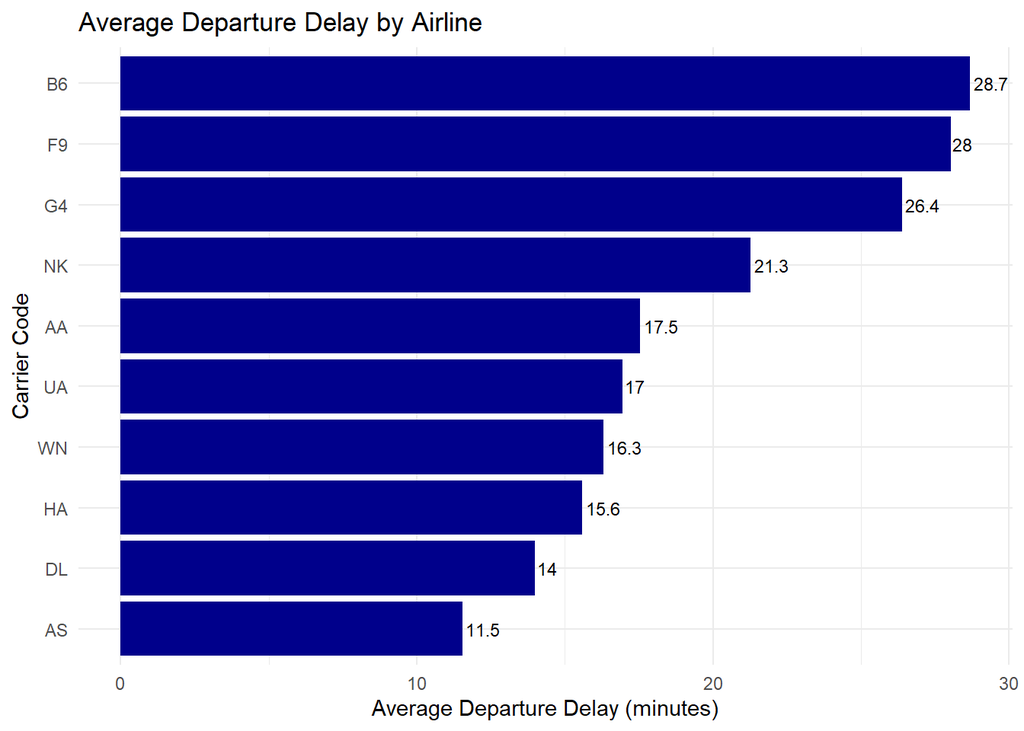

```r
flights_db %>%
  group_by(Marketing_Airline_Network) %>%
  summarise(avg_dep_delay = mean(DepDelayMinutes, na.rm = TRUE)) %>%
  arrange(desc(avg_dep_delay)) %>%
  ggplot(aes(x = reorder(Marketing_Airline_Network, avg_dep_delay), y = avg_dep_delay)) +
  geom_bar(stat = "identity", fill = 'darkblue') +
  geom_text(aes(label = round(avg_dep_delay, 1)),  # Add rounded labels
            position = position_dodge(width = 0.9),  # Adjust position to align with bars
            hjust = -0.1,  # Adjust horizontal position to be outside of the bar
            size = 3) +  # Set text size
  coord_flip() +  # Flips the coordinates to make horizontal bars
  theme_minimal() +
  labs(title = "Average Departure Delay by Airline",
       x = "Carrier Code",
       y = "Average Departure Delay (minutes)")
```

### View average departure delay by carrier name

In order to bring in carrier name, we need to join to the carriers table like we did with the sample data.

#### Use SQL code to query

```r
sql <- "
SELECT c.CarrierName, AVG(f.DepDelayMinutes) AS avg_dep_delay
FROM flights f
LEFT JOIN carrier_tbl c ON f.Marketing_Airline_Network = c.Code
GROUP BY CarrierName
ORDER BY avg_dep_delay DESC
"
```

```r
dbGetQuery(con, sql)
```

```
              CarrierName avg_dep_delay
1         JetBlue Airways      28.68281
2  Frontier Airlines Inc.      28.03174
3           Allegiant Air      26.38167
4        Spirit Air Lines      21.26989
5  American Airlines Inc.      17.54567
6   United Air Lines Inc.      16.95852
7  Southwest Airlines Co.      16.30807
8  Hawaiian Airlines Inc.      15.58884
9    Delta Air Lines Inc.      13.99643
10   Alaska Airlines Inc.      11.53159
```

#### Use `dbplyr` to query

In order to join on the carriers table, we want to convert the carriers table into a database object using `tbl()`.

```r
carriers_db <- tbl(con, 'carrier_tbl')
```

Next, we can use `dplyr` syntax to join and calculate average departure delay by carrier name. Let’s write our code and look at our query.

```r
flights_db %>% left_join(
    x = flights_db,
    y = carriers_db,
    by = join_by(Marketing_Airline_Network == Code)
    ) %>%
  group_by(CarrierName) %>%
  summarise(avg_dep_delay = mean(DepDelayMinutes, na.rm = TRUE)) %>%
  arrange(desc(avg_dep_delay)) %>%
  show_query()
```

```
<SQL>
SELECT CarrierName, AVG(DepDelayMinutes) AS avg_dep_delay
FROM (
  SELECT flights.*, CarrierName
  FROM flights
  LEFT JOIN carrier_tbl
    ON (flights.Marketing_Airline_Network = carrier_tbl.Code)
) q01
GROUP BY CarrierName
ORDER BY avg_dep_delay DESC
```

Now let’s execute to look at the results as a table and then as a visualization.

```r
flights_db %>% left_join(
    x = flights_db,
    y = carriers_db,
    by = join_by(Marketing_Airline_Network == Code)
    ) %>%
  group_by(CarrierName) %>%
  summarise(avg_dep_delay = mean(DepDelayMinutes, na.rm = TRUE)) %>%
  arrange(desc(avg_dep_delay))
```

```
# Source:     SQL [10 x 2]
# Database:   DuckDB v0.9.2 [dmark@Windows 10 x64:R 4.3.1/:memory:]
# Ordered by: desc(avg_dep_delay)
   CarrierName            avg_dep_delay
   <chr>                          <dbl>
 1 JetBlue Airways                 28.7
 2 Frontier Airlines Inc.          28.0
 3 Allegiant Air                   26.4
 4 Spirit Air Lines                21.3
 5 American Airlines Inc.          17.5
 6 United Air Lines Inc.           17.0
 7 Southwest Airlines Co.          16.3
 8 Hawaiian Airlines Inc.          15.6
 9 Delta Air Lines Inc.            14.0
10 Alaska Airlines Inc.            11.5
```

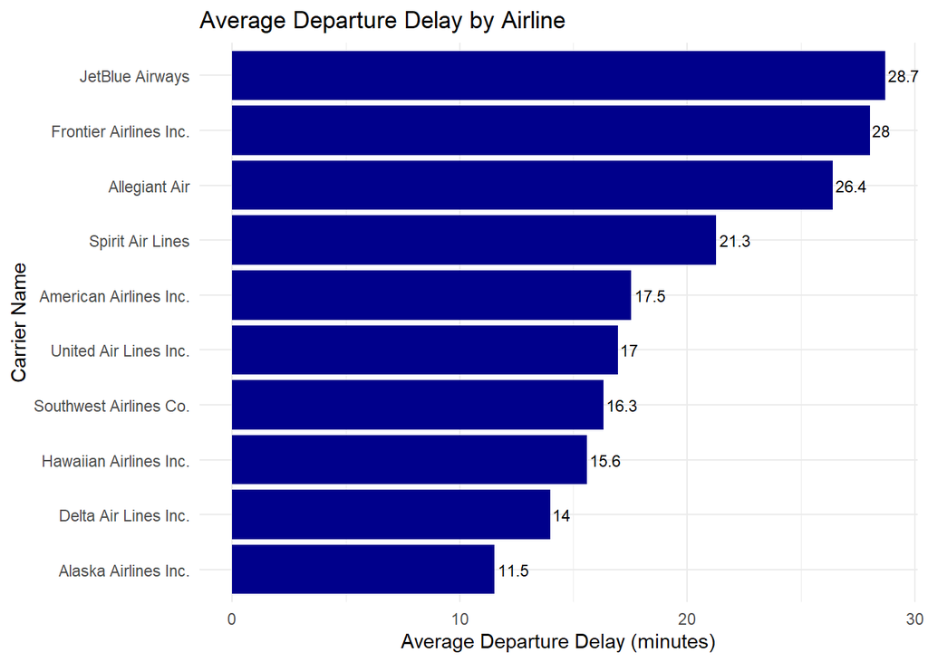

```r
flights_db %>% left_join(
    x = flights_db,
    y = carriers_db,
    by = join_by(Marketing_Airline_Network == Code)
    ) %>%
  group_by(CarrierName) %>%
  summarise(avg_dep_delay = mean(DepDelayMinutes, na.rm = TRUE)) %>%
  arrange(desc(avg_dep_delay)) %>%
  ggplot(aes(x = reorder(CarrierName, avg_dep_delay), y = avg_dep_delay)) +
  geom_bar(stat = "identity", fill = 'darkblue') +
  geom_text(aes(label = round(avg_dep_delay, 1)),  # Add rounded labels
            position = position_dodge(width = 0.9),  # Adjust position to align with bars
            hjust = -0.1,  # Adjust horizontal position to be outside of the bar
            size = 3) +  # Set text size
  coord_flip() +  # Flips the coordinates to make horizontal bars
  theme_minimal() +
  labs(title = "Average Departure Delay by Airline",
       x = "Carrier Name",
       y = "Average Departure Delay (minutes)")
```

### Class Exercise

Create a visualization showing average departure delay by month in 2022.

## Disconnect from DB

When finished with querying the database, disconnect.

```r
dbDisconnect(con)
```